# Outlier Identification

## Introduction

This notebook has been used to indentify outliers in the dataset. The purpose is that of identifying a **list of names** that can be used to *pop* the data dictionary.  
I am going to use a series of supporting functions, in particular a plotting function (based on matplotlib.pyplot).

## Importing data

I import the Enron data dictionary and I convert it into a pandas dataframe (indexes correspond to names).

```python
import pickle
import pandas as pd
import numpy as np

# Charting modules
%matplotlib inline
import matplotlib.pyplot
from ggplot import *

# User-created modules
import sys
sys.path.append('../tools')
import dict_parser
```

```python
with open("../data/final_project_dataset.pkl", "r") as data_file:
    data_dict = pickle.load(data_file)
```

```python
dataset = dict_parser.convert_into_df(data_dict)
```

```python
# Define poi as boolean
dataset['poi'] = dataset['poi'].astype('bool')
```

## Visualisation

Here, I would like to plot some variables against each other to eventually spot some possible outliers. I progressively add outliers to the list *outlier* here defined. I have also added a function called **plot** which print charts usefult for visualising relationships.

```python
# Initialise outliers list
outliers = []
```

```python
def plot(df, x, y, x_type = 'min', y_type = 'min'):

    """

        This function generates a chart that is used to identify possible
        poi-explanatory relationships betwen variables x and y.

    """

    # Define coordinates for horizontala and vertical lines
    horiz_coord = getattr(np, y_type)(df[df['poi'] == 1][y])
    vertic_coord = getattr(np, x_type)(df[df['poi'] == 1][x])

    gg = ggplot(df, aes(x = x, y = y, color = 'poi')) +\
        geom_point(size = 60, alpha = 0.8) +\
        scale_color_manual(values = ['#8cb1f0', '#f40000']) +\
        theme_bw() +\
        geom_hline(y = horiz_coord, color = 'black', size = 0.5, linetype = 'dashed') +\
        geom_vline(x = vertic_coord, color = 'black', size = 0.5, linetype = 'dashed')

    return gg
```

### Financial Variables

Let me start with financial variables. An outlier has actually been already identified in class, but I will show it again.

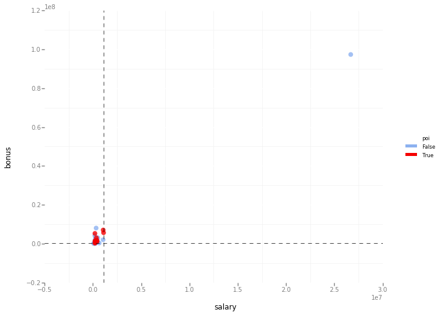

```python
plot(dataset, 'salary', 'bonus', x_type = 'max')
```

There is clearly an outlier here, i.e. an observation with a much higher salary and bonus. Let me check who he is.

```python
dataset[dataset['salary'] > 1e7][['name', 'salary']]
```

|  | name | salary |
| --- | --- | --- |
| 104 | TOTAL | 26704229.0 |

The TOTAL' observation is actually the sum of all the others values. Let me add it to the outliers list and remove the observation from the dataset.

```python
outliers.append('TOTAL')
dataset = dataset[dataset['name'] != 'TOTAL']
```

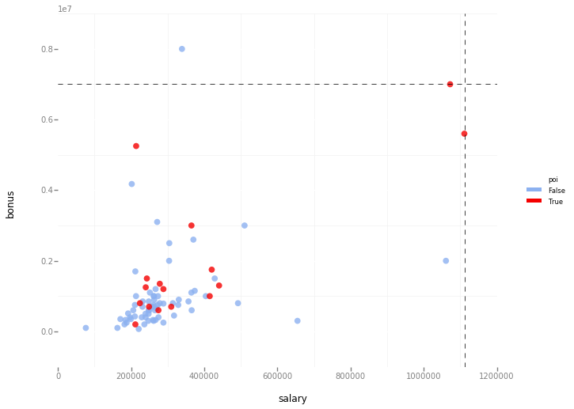

```python
plot(dataset, 'salary', 'bonus', x_type = 'max', y_type = 'max')
```

Much better now. There are obviously observations with a much higher salary/bonus, but I expected that.

### Messages variables

Let me explore some outliers for messages variables.

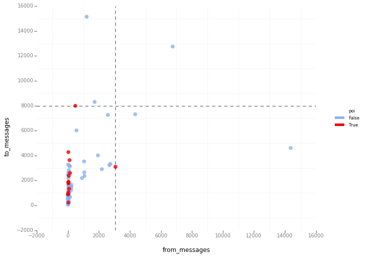

```python
plot(dataset, 'from_messages', 'to_messages', x_type = 'max', y_type = 'max')
```

I notice three obseravtions here which are quite unusual. They are people who have sent and/or received a very high number of emails. They are not POIs. Let me figure out who they are.

```python
indexing = (dataset['from_messages'] > 14000) | (dataset['to_messages'] > 12000)
dataset[indexing]['name']
```

```
51       SHAPIRO RICHARD S
89     KAMINSKI WINCENTY J
103          KEAN STEVEN J
Name: name, dtype: object
```

I will remove these observations from the final dataset. Let me add them to the outliers list.

```python
outliers += dataset[indexing]['name'].values.tolist()
dataset = dataset[np.invert(indexing)]
```

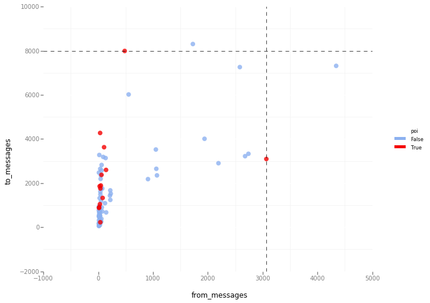

```python
plot(dataset, 'from_messages', 'to_messages', x_type = 'max', y_type = 'max')
```

### Missing values

Since the beginning of this project, I have been thinking about how to treat 'NaN's, i.e. missing values. The code provided by Udacity transforms NaN values into zero, which may not be the best answer, but it is no different than assigning any other value.  
My approach then is that of working *ex-ante*, i.e. by looking at observations with a high percentage of NaN values (i.e. observations which are not really adding too much value to the dataset) and potentially remove them.

```python
fields = ['name', 'nan_percentage', 'poi']
values = []
for name, obs_dict in data_dict.items():
    obs_list = [name]
    nan_counter = 0
    length = len(obs_dict) - 2
    for key, value in obs_dict.items():
        if key != 'email_address':
            if key == 'poi':
                poi = value
            elif value == 'NaN':
                nan_counter += 1
    obs_list.append(float(nan_counter)/ length)
    obs_list.append(poi)
    values.append(obs_list)

check_df = pd.DataFrame(values, columns=fields)
check_df.sort_values(by = 'nan_percentage', ascending=False).head(10)
```

|  | name | nan_percentage | poi |
| --- | --- | --- | --- |
| 90 | LOCKHART EUGENE E | 1.000000 | False |
| 73 | SCRIMSHAW MATTHEW | 0.894737 | False |
| 101 | THE TRAVEL AGENCY IN THE PARK | 0.894737 | False |
| 26 | WODRASKA JOHN | 0.894737 | False |
| 62 | WROBEL BRUCE | 0.894737 | False |
| 31 | WHALEY DAVID A | 0.894737 | False |
| 141 | GRAMM WENDY L | 0.894737 | False |
| 37 | CLINE KENNETH W | 0.842105 | False |
| 136 | SAVAGE FRANK | 0.842105 | False |
| 77 | GILLIS JOHN | 0.842105 | False |

It is obvious that there is a lot of missing data!  
There is, however, a person whose information are completely missing, except for his name, his e-mail address and his poi status (he is not a poi). This person is LOCKHART EUGENE E, whom I will remove as an outlier.  
There is also an observation called 'THE TRAVEL AGENCY IN THE PARK', which also has a lot of missing data. In general, my approach would have been that of keeping all the observations (unless the percentage of NaN is 100%, like in the case of Lockhart Eugene E). In this case, however, the travel agency represents a business, not a person. I will remove it too.

```python
outliers.append('LOCKHART EUGENE E')
outliers.append('THE TRAVEL AGENCY IN THE PARK')
```

#### Missing values by type of variables

The analysis above, however, was counting the percentage of missing values for all features. I would like to perform the same analysis by splitting in financial variables and message variables. Let me just change the code above a little bit.

```python
fin_variables = ['salary', 'deferral_payments', 'total_payments',
                 'loan_advances', 'bonus', 'restricted_stock_deferred',
                 'deferred_income', 'total_stock_value', 'expenses',
                 'exercised_stock_options', 'other', 'long_term_incentive',
                 'restricted_stock', 'director_fees']

# I have excluded e_mail address from message variables since
# I wouldn't use this variable anyway
message_variables = ['to_messages', 'from_poi_to_this_person',
                     'from_messages', 'from_this_person_to_poi', 'shared_receipt_with_poi']
```

```python
# Define length of financial variables array
len_fin = len(fin_variables)

# Define length of message variables
len_message = len(message_variables)

# Define general list which will store observation lists
general_list = []

for name, obs_dict in data_dict.items():
    obs_list = [name]
    nan_fin = 0
    nan_message = 0
    for key, value in obs_dict.items():
        if key in fin_variables:
            if value == 'NaN':
                nan_fin += 1
        if key in message_variables:
            if value == 'NaN':
                nan_message += 1
        if key == 'poi':
            poi = value

    nan_fin_ratio = float(nan_fin) / len_fin
    nan_message_ratio = float(nan_message) / len_message
    nan_total_ratio = float((nan_fin + nan_message)) / float((len_fin + len_message))

    obs_list.append(nan_total_ratio)
    obs_list.append(nan_fin_ratio)
    obs_list.append(nan_message_ratio)
    obs_list.append(poi)
    general_list.append(obs_list)
```

```python
# Fields
fields = ['name', 'nan_percentage_total',
          'nan_percentage_fin',
          'nan_percentage_message','poi']
check_df = pd.DataFrame(general_list, columns=fields)
```

```python
def sorter(df, column, ascending=False):

    """

        This function is used to sort the dataframe for checking
        the percentage of NaN by different columns

    """

    return df.sort_values(by = column, ascending = ascending)
```

#### Percentage of NaN (total)

```python
sorter(check_df, 'nan_percentage_total').head(20)
```

|  | name | nan_percentage_total | nan_percentage_fin | nan_percentage_message | poi |
| --- | --- | --- | --- | --- | --- |
| 90 | LOCKHART EUGENE E | 1.000000 | 1.000000 | 1.0 | False |
| 73 | SCRIMSHAW MATTHEW | 0.894737 | 0.857143 | 1.0 | False |
| 101 | THE TRAVEL AGENCY IN THE PARK | 0.894737 | 0.857143 | 1.0 | False |
| 26 | WODRASKA JOHN | 0.894737 | 0.857143 | 1.0 | False |
| 62 | WROBEL BRUCE | 0.894737 | 0.857143 | 1.0 | False |
| 31 | WHALEY DAVID A | 0.894737 | 0.857143 | 1.0 | False |
| 141 | GRAMM WENDY L | 0.894737 | 0.857143 | 1.0 | False |
| 37 | CLINE KENNETH W | 0.842105 | 0.785714 | 1.0 | False |
| 136 | SAVAGE FRANK | 0.842105 | 0.785714 | 1.0 | False |
| 77 | GILLIS JOHN | 0.842105 | 0.785714 | 1.0 | False |
| 46 | WAKEHAM JOHN | 0.842105 | 0.785714 | 1.0 | False |
| 108 | CHRISTODOULOU DIOMEDES | 0.842105 | 0.785714 | 1.0 | False |
| 96 | BLAKE JR. NORMAN P | 0.789474 | 0.714286 | 1.0 | False |
| 35 | MENDELSOHN JOHN | 0.789474 | 0.714286 | 1.0 | False |
| 112 | WINOKUR JR. HERBERT S | 0.789474 | 0.714286 | 1.0 | False |
| 28 | URQUHART JOHN A | 0.789474 | 0.714286 | 1.0 | False |
| 64 | MEYER JEROME J | 0.789474 | 0.714286 | 1.0 | False |
| 23 | CHAN RONNIE | 0.789474 | 0.714286 | 1.0 | False |
| 121 | YEAP SOON | 0.789474 | 0.714286 | 1.0 | False |
| 74 | GATHMANN WILLIAM D | 0.789474 | 0.714286 | 1.0 | False |

#### Percentage of NaN (financial)

```python
sorter(check_df, 'nan_percentage_fin').head(8)
```

|  | name | nan_percentage_total | nan_percentage_fin | nan_percentage_message | poi |
| --- | --- | --- | --- | --- | --- |
| 90 | LOCKHART EUGENE E | 1.000000 | 1.000000 | 1.0 | False |
| 73 | SCRIMSHAW MATTHEW | 0.894737 | 0.857143 | 1.0 | False |
| 113 | BROWN MICHAEL | 0.631579 | 0.857143 | 0.0 | False |
| 59 | PIRO JIM | 0.631579 | 0.857143 | 0.0 | False |
| 47 | POWERS WILLIAM | 0.631579 | 0.857143 | 0.0 | False |
| 38 | LEWIS RICHARD | 0.631579 | 0.857143 | 0.0 | False |
| 101 | THE TRAVEL AGENCY IN THE PARK | 0.894737 | 0.857143 | 1.0 | False |
| 62 | WROBEL BRUCE | 0.894737 | 0.857143 | 1.0 | False |

#### Percentage of NaN (messages)

```python
sorter(check_df, 'nan_percentage_message').head()
```

|  | name | nan_percentage_total | nan_percentage_fin | nan_percentage_message | poi |
| --- | --- | --- | --- | --- | --- |
| 73 | SCRIMSHAW MATTHEW | 0.894737 | 0.857143 | 1.0 | False |
| 54 | LEMAISTRE CHARLES | 0.736842 | 0.642857 | 1.0 | False |
| 63 | LINDHOLM TOD A | 0.473684 | 0.285714 | 1.0 | False |
| 62 | WROBEL BRUCE | 0.894737 | 0.857143 | 1.0 | False |
| 61 | SULLIVAN-SHAKLOVITZ COLLEEN | 0.578947 | 0.428571 | 1.0 | False |

## Final list of outliers

The final list of outliers is reported below.

```python
outliers
```

```
['TOTAL',
 'SHAPIRO RICHARD S',
 'KAMINSKI WINCENTY J',
 'KEAN STEVEN J',
 'LOCKHART EUGENE E',
 'THE TRAVEL AGENCY IN THE PARK']
```